# Exercicios Capitulos 2 e 3

Larissa Garcez Ribeiro

2026-03-24

# Capítulo 3 — Reprodutibilidade

## Git e GitHub

### Exercício 1 (Fácil)

Criei uma conta no GitHub e configurei o Git no computador com nome e e-mail usando o Terminal do RStudio:

```
git config --global user.name "LarissaGarcez"
git config --global user.email "larissagarcez@usp.br"
```

### Exercício 2 (Fácil)

Criei o repositório “exercicio-stat-basica” no GitHub e clonei no RStudio via File > New Project > Version Control > Git.

### Exercício 3 (Médio)

Criei o arquivo `scripts/analise.R` com um código simples e realizei o ciclo completo: stage, commit e push.

```
git add scripts/analise.R
git commit -m "Adiciona código de análise exploratória"
git push
```

### Exercício 4 (Médio)

Modifiquei o arquivo `analise.R` adicionando mais linhas de código e fiz um novo commit e push. O histórico de commits pode ser visto no GitHub.

### Exercício 5 (Médio)

Criei a branch `experimento`, modifiquei o `analise.R` adicionando `median(x)`, fiz commit na branch e depois voltei para a `main` e realizei o merge.

```
git checkout -b experimento
git merge experimento
```

## R Markdown

### Exercício 1 (Fácil)

Este documento foi criado como um arquivo R Markdown no RStudio via File > New File > R Markdown, escolhendo o formato HTML. O botão Knit foi usado para renderizar o documento.

### Exercício 2 (Médio)

Abaixo está um exemplo com texto formatado, lista numerada e um chunk de código R:

**Texto em negrito** e *texto em itálico*.

Lista numerada:

1. Primeiro item
2. Segundo item
3. Terceiro item

```r
# Calculando a média de um vetor
x <- c(10, 20, 30, 40, 50)
mean(x)
```

```
## [1] 30
```

### Exercício 3 (Médio)

Abaixo importamos o banco de dados e apresentamos as 10 primeiras linhas e um gráfico:

| nome_munic | sigla_uf | pib_total | pib_per_capita |
| --- | --- | --- | --- |
| Alta Floresta D’Oeste | RO | 341324.69 | 13266.66 |
| Ariquemes | RO | 1799852.51 | 17772.99 |
| Cabixi | RO | 96364.54 | 14836.73 |
| Cacoal | RO | 1433253.51 | 16692.33 |
| Cerejeiras | RO | 353269.68 | 19581.49 |
| Colorado do Oeste | RO | 242767.24 | 12650.72 |
| Corumbiara | RO | 168680.59 | 18667.62 |
| Costa Marques | RO | 149738.83 | 9445.46 |
| Espigão D’Oeste | RO | 426546.22 | 13456.14 |
| Guajará-Mirim | RO | 605130.83 | 13223.72 |

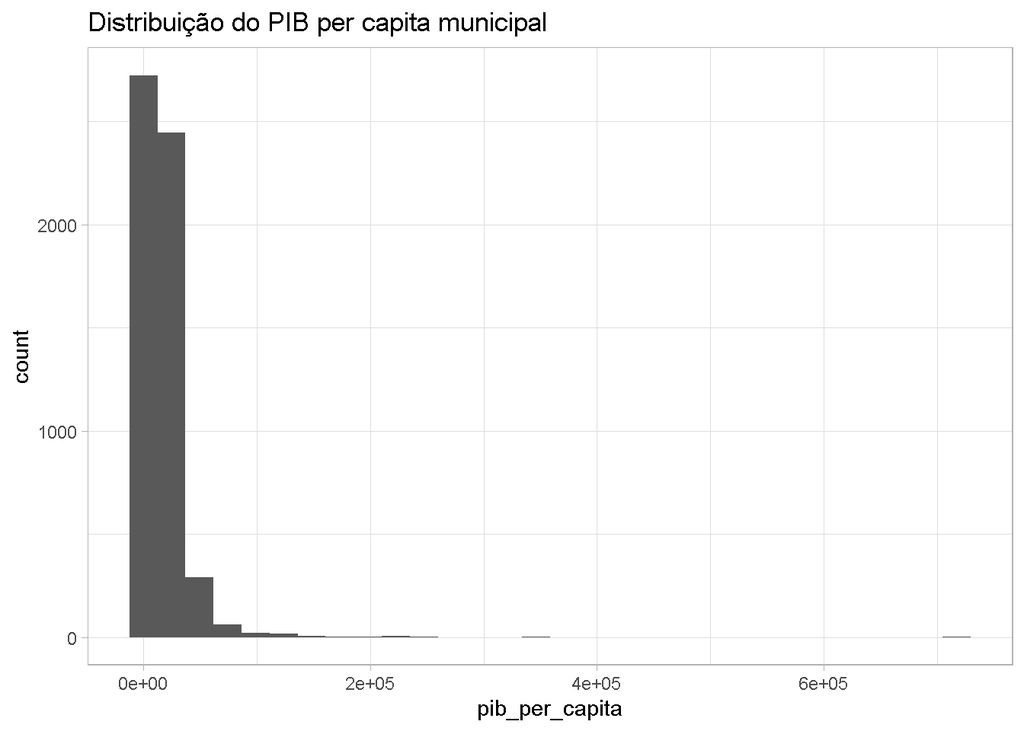

# Capítulo 2 — Introdução ao R e RStudio

## Importação de dados

### Exercício 1 (Fácil)

```r
mun <- read.csv("../dados/municipios_virgula.csv")
nrow(mun)
```

```
## [1] 15
```

```r
names(mun)
```

```
## [1] "nome_municipio" "uf"             "populacao"      "idh"
## [5] "pib_per_capita"
```

### Exercício 2 (Fácil)

```r
# Tentativa com read.csv() - separador errado
mun_erro <- read.csv("../dados/municipios_pontovirgula.csv")
```

```
## Error in read.table(file = file, header = header, sep = sep, quote = quote, : more columns than column names
```

```r
head(mun_erro, 2)
```

```
## Error in head(mun_erro, 2): objeto 'mun_erro' não encontrado
```

```r
# Importação correta com read.csv2()
mun2 <- read.csv2("../dados/municipios_pontovirgula.csv", fileEncoding = "latin1")
head(mun2, 2)
```

```
##   nome_municipio uf populacao   idh pib_per_capita
## 1      São Paulo SP  11451999 0.805       54258.31
## 2 Rio de Janeiro RJ   6211423 0.799       49527.98
```

O `read.csv()` usa vírgula como separador por padrão. O `read.csv2()` usa ponto e vírgula, adequado para arquivos no padrão brasileiro.

### Exercício 3 (Médio)

```r
eleicoes <- read.csv("../dados/eleicoes_2022.csv")
library(dplyr)
filter(eleicoes, municipio == "Pau D'Arco")
```

```
##    municipio uf candidato partido votos percentual
## 1 Pau D'Arco PA      Lula      PT  2345      55.37
## 2 Pau D'Arco PA Bolsonaro      PL  1890      44.63
```

### Exercício 4 (Médio)

```r
idh <- read.csv2("../dados/idh_municipios.csv", fileEncoding = "latin1")
str(idh)
```

```
## 'data.frame':    25 obs. of  9 variables:
##  $ cod_ibge       : int  3550308 3304557 3106200 2927408 4106902 2304400 1302603 2611606 4314902 1501402 ...
##  $ municipio      : chr  "São Paulo" "Rio de Janeiro" "Belo Horizonte" "Salvador" ...
##  $ uf             : chr  "SP" "RJ" "MG" "BA" ...
##  $ regiao         : chr  "Sudeste" "Sudeste" "Sudeste" "Nordeste" ...
##  $ idh_2010       : num  0.805 0.799 0.81 0.759 0.823 0.754 0.737 0.772 0.805 0.746 ...
##  $ idh_educacao   : num  0.725 0.719 0.737 0.661 0.768 0.672 0.658 0.698 0.727 0.673 ...
##  $ idh_longevidade: num  0.855 0.845 0.856 0.835 0.855 0.824 0.812 0.825 0.857 0.818 ...
##  $ idh_renda      : num  0.843 0.84 0.841 0.79 0.85 0.773 0.75 0.798 0.835 0.756 ...
##  $ populacao_2010 : int  11253503 6320446 2375151 2675656 1751907 2452185 1802014 1537704 1409351 1393399 ...
```

## Data Wrangling com dplyr

### Exercício 1 (Fácil)

```r
# Município com maior e menor IDH
mun %>% filter(idh == max(idh)) %>% select(nome_municipio, idh)
```

```
##   nome_municipio   idh
## 1  Florianópolis 0.847
```

```r
mun %>% filter(idh == min(idh)) %>% select(nome_municipio, idh)
```

```
##   nome_municipio   idh
## 1     Pau D'Arco 0.567
```

### Exercício 2 (Fácil)

```r
# População total e média
mun %>% summarise(pop_total = sum(populacao), pop_media = mean(populacao))
```

```
##   pop_total pop_media
## 1  36601670   2440111
```

### Exercício 3 (Médio)

```r
# Total de votos por candidato, ordenado do mais votado
eleicoes %>%
  group_by(candidato) %>%
  summarise(total_votos = sum(votos)) %>%
  arrange(desc(total_votos))
```

```
## # A tibble: 4 × 2
##   candidato    total_votos
##   <chr>              <int>
## 1 Lula             8249244
## 2 Bolsonaro        6861801
## 3 Simone Tebet      758133
## 4 Ciro Gomes        355023
```

### Exercício 4 (Médio)

```r
# IDH médio por região
idh %>%
  group_by(regiao) %>%
  summarise(idh_medio = mean(idh_2010)) %>%
  arrange(desc(idh_medio))
```

```
## # A tibble: 5 × 2
##   regiao       idh_medio
##   <chr>            <dbl>
## 1 Sul              0.825
## 2 Centro-Oeste     0.798
## 3 Sudeste          0.796
## 4 Nordeste         0.758
## 5 Norte            0.752
```

### Exercício 5 (Médio)

```r
# Vencedor por município
eleicoes %>%
  group_by(municipio) %>%
  slice_max(percentual, n = 1) %>%
  select(municipio, candidato, percentual)
```

```
## # A tibble: 7 × 3
## # Groups:   municipio [7]
##   municipio           candidato percentual
##   <chr>               <chr>          <dbl>
## 1 Belo Horizonte      Lula            52.6
## 2 Florianópolis       Bolsonaro       57.1
## 3 Pau D'Arco          Lula            55.4
## 4 Rio de Janeiro      Lula            49.6
## 5 Salvador            Lula            64.0
## 6 São José dos Campos Bolsonaro       55.3
## 7 São Paulo           Lula            48.8
```

## Visualização com ggplot2

### Exercício 1 (Fácil)

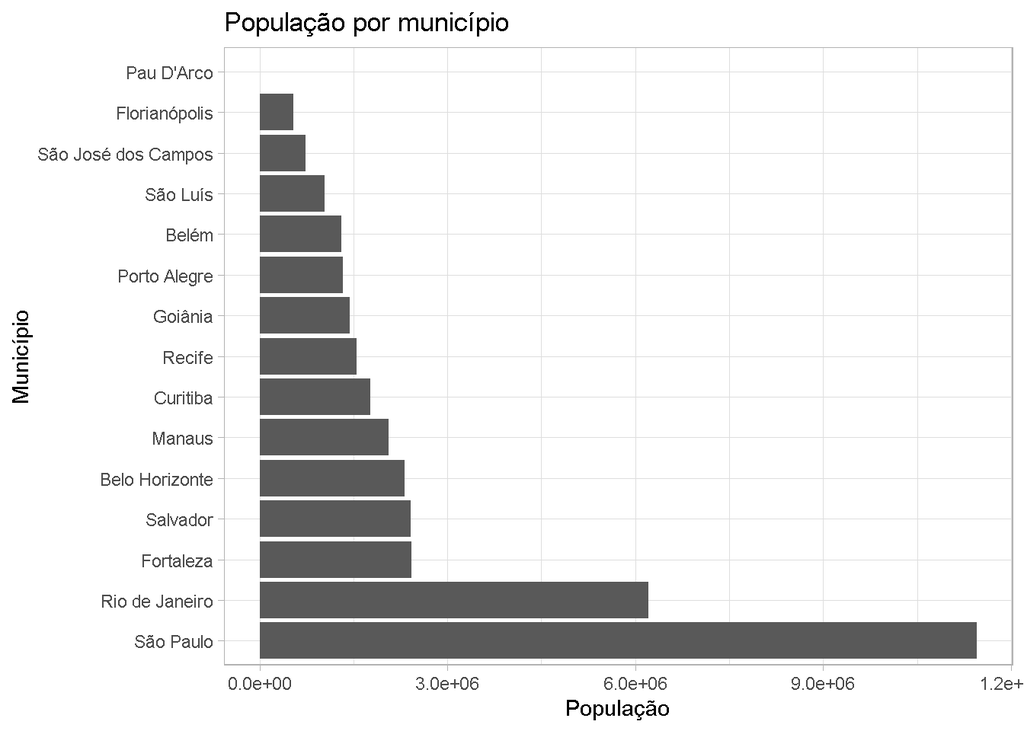

```r
library(ggplot2)
mun %>%
  ggplot(aes(x = reorder(nome_municipio, -populacao), y = populacao)) +
  geom_col() +
  coord_flip() +
  xlab("Município") +
  ylab("População") +
  ggtitle("População por município") +
  theme_light()
```

### Exercício 2 (Médio)

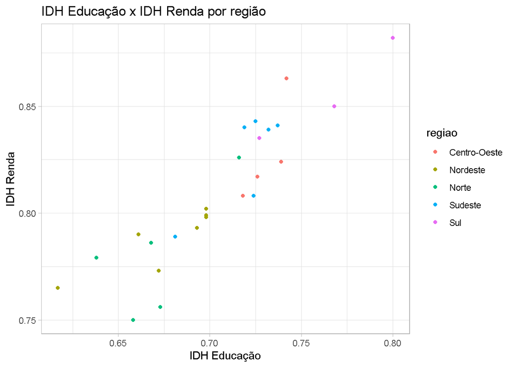

```r
idh %>%
  ggplot(aes(x = idh_educacao, y = idh_renda, color = regiao)) +
  geom_point() +
  xlab("IDH Educação") +
  ylab("IDH Renda") +
  ggtitle("IDH Educação x IDH Renda por região") +
  theme_light()
```

## Workflow

### Exercício 1 (Médio)

A estrutura de pastas do projeto foi criada seguindo a convenção recomendada:

```
exercicio-stat-basica/
├── dados/          # arquivos de dados
├── scripts/        # scripts R
├── outputs/        # tabelas e figuras
├── paper/          # este documento Rmd
└── README.md       # instruções do projeto
```

O projeto foi inicializado como repositório Git e o primeiro commit foi realizado com a mensagem “Adiciona estrutura inicial do projeto”.